# PD6

Adam Rydelek

28 - 05 - 2019

# 1 Wprowadzenie

W ramach pracy domowej porównam różne statystyki walidacyjne klasteryzacji na trzech modelach: `kmeans`, `hclust` i `pam`. Do tego celu wykorzystam zbiór [Mall_Customers](https://www.kaggle.com/vjchoudhary7/customer-segmentation-tutorial-in-python) z kaggle.

## 1.1 Wybór badanej liczby klastrów

Aby wybrać odpowiednią liczbę klastrów wykorzystamy pakiet `factoextra`, za pomocą którego wykonamy wykres porównujący statystykę **gap** dla różnej liczby klastrów.

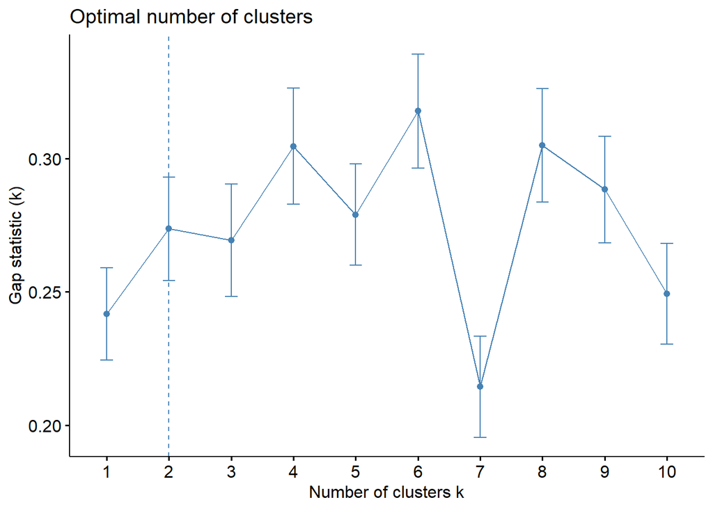

```r
fviz_nbclust(Data, kmeans, method = "gap_stat")
```

Za pomocą powyższego wykresu uznałem, że przeprowadzimy dalsze testy na **2**, **6** i **8** klastrach.

## 1.2 Wizualizacja poszczególnych modeli

Aby zobaczyć jak dobrze wybrane modele dzielą zbiór na klastry porównamy **PAM** i **kmeans** na 6 klastrach, które według powyższej statystyki są najbardziej optymalne.

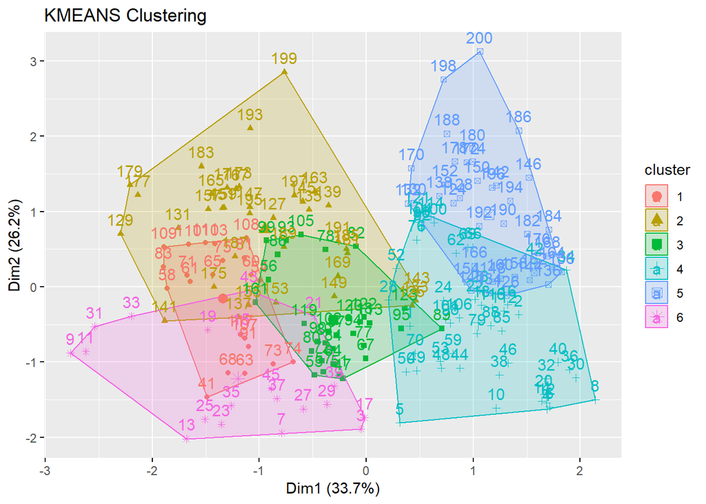

```r
a1 <- eclust(Data, 'kmeans', k = 2, graph=FALSE)
b1 <- eclust(Data, 'pam', k = 2, graph=FALSE)
c1 <- eclust(Data, 'hclust', k=2, graph=FALSE)
a6 <- eclust(Data, 'kmeans', k = 6)
```

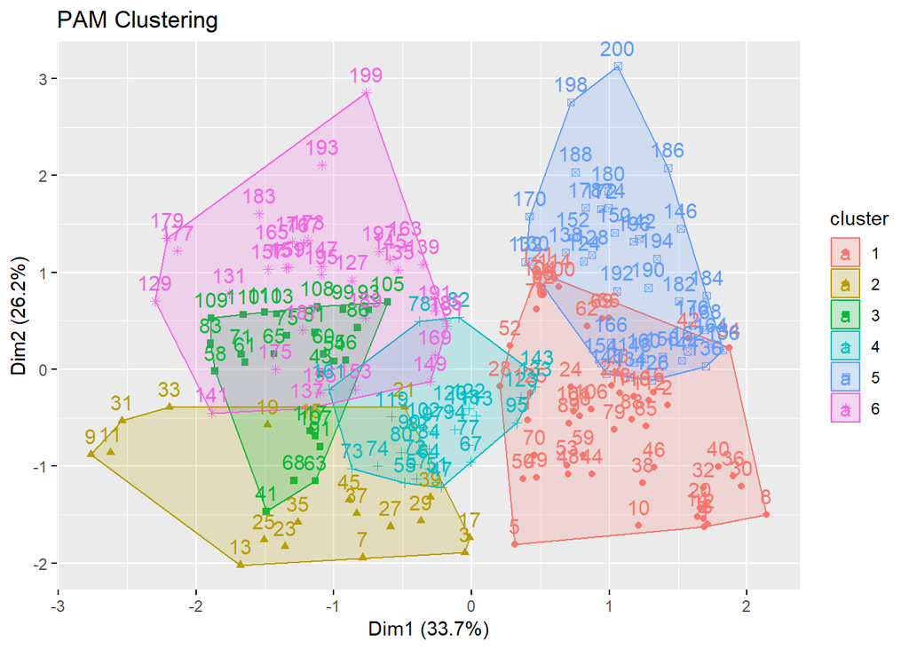

```r
b6 <- eclust(Data, 'pam', k = 6)
```

```r
c6 <- eclust(Data, 'hclust', k=6)
a8 <- eclust(Data, 'kmeans', k = 8, graph=FALSE)
b8 <- eclust(Data, 'pam', k = 8, graph=FALSE)
c8 <- eclust(Data, 'hclust', k=8, graph=FALSE)
```

Można zauważyć, że generalny kształt klastrów jest podobny między modelami, jednak widać spore różnice w ich kształcie, zobaczymy teraz jak wpłynie ta różnica na statystyki.

# 2 Statystyki jakości

## 2.1 Porównanie za pomocą clValid

Najpierw zajmę się statystykami *internal*. Do początkowej oceny wykorzystam pakiet `clValid`. Porównuje on trzy statystyki: *Conectivity*, *Dunn Index*, oraz *Silhouette*.

### 2.1.1 Statystyki nieporównawcze

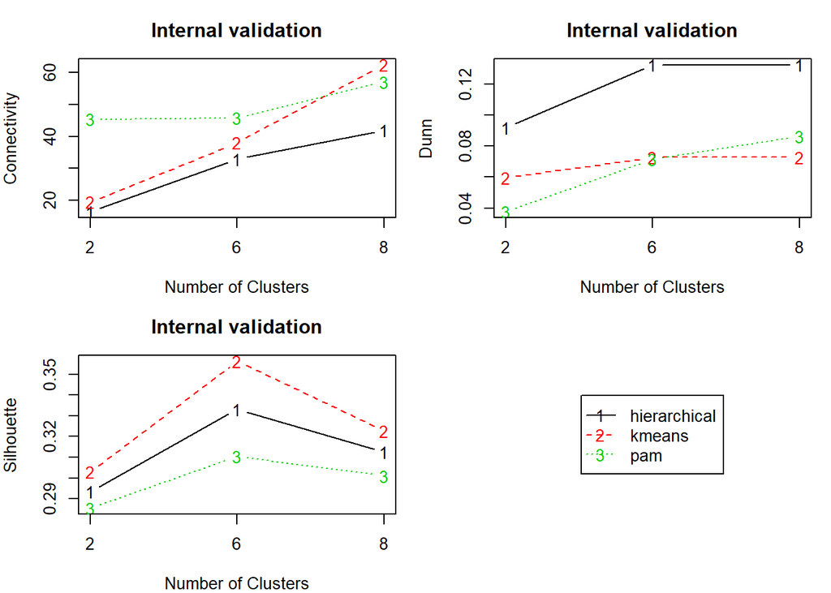

```r
intern <- clValid(Data, c(2,6,8), clMethods=c("hierarchical","kmeans","pam"),validation="internal")
op <- par(no.readonly=TRUE)
par(mfrow=c(2,2),mar=c(4,4,3,1))
plot(intern, legend=FALSE)
plot(nClusters(intern),measures(intern,"Dunn")[,,1],type="n",axes=F,xlab="",ylab="")
legend("center", clusterMethods(intern), col=1:9, lty=1:9, pch=paste(1:9))
```

Jako, że wartość *Conectivity* minimalizujemy, a *Dunn* i *Silhouette* maksymalizujemy można zauważyć, że najlepsze okazały się:

```r
z <- data.frame(Score=c(16.4485, 0.1325, 0.3562), Method=c('hclust','hclust','kmeans'), Clusters=c(2,6,6))
rownames(z) <- c('Connectivity','Dunn','Silhouette')
knitr::kable(z)
```

|  | Score | Method | Clusters |
| --- | --- | --- | --- |
| Connectivity | 16.4485 | hclust | 2 |
| Dunn | 0.1325 | hclust | 6 |
| Silhouette | 0.3562 | kmeans | 6 |

## 2.2 Statystyki z artykułu

Teraz porównam statystyki nieporównawcze: *Dunn Index*, *Gamma Statistic*, *Entropy*, oraz statystykę porównawczą: indeks *Fowlkesa-Mallowsa*.

### 2.2.1 Statystyki nieporównawcze

```r
kmeans1 <- cluster.stats(dist(Data),  a1$cluster)
kmeans2 <- cluster.stats(dist(Data),  a6$cluster)
kmeans3 <- cluster.stats(dist(Data),  a8$cluster)
pam1 <- cluster.stats(dist(Data),  b1$cluster)
pam2 <- cluster.stats(dist(Data),  b6$cluster)
pam3 <- cluster.stats(dist(Data),  b8$cluster)
hclust1 <- cluster.stats(dist(Data), c1$cluster)
hclust2 <- cluster.stats(dist(Data), c6$cluster)
hclust3 <- cluster.stats(dist(Data), c8$cluster)

knitr::kable(data.frame(clusters=c(2,6,8),kmeans=c(kmeans1$dunn, kmeans2$dunn, kmeans3$dunn), pam=c(pam1$dunn,pam2$dunn,pam3$dunn), hclust=c(hclust1$dunn,hclust2$dunn,hclust3$dunn)), caption='Dunn Index')
```

Dunn Index

| clusters | kmeans | pam | hclust |
| --- | --- | --- | --- |
| 2 | 0.0595666 | 0.0376595 | 0.0992052 |
| 6 | 0.0727634 | 0.0716372 | 0.1419601 |
| 8 | 0.0727634 | 0.0861120 | 0.1322319 |

```r
knitr::kable(data.frame(clusters=c(2,6,8),kmeans=c(kmeans1$pearsongamma, kmeans2$pearsongamma, kmeans3$pearsongamma), pam=c(pam1$pearsongamma,pam2$pearsongamma,pam3$pearsongamma), hclust=c(hclust1$pearsongamma,hclust2$pearsongamma,hclust3$pearsongamma)), caption='Pearson Gamma')
```

Pearson Gamma

| clusters | kmeans | pam | hclust |
| --- | --- | --- | --- |
| 2 | 0.4809749 | 0.4531505 | 0.4640198 |
| 6 | 0.5381132 | 0.5345816 | 0.5692878 |
| 8 | 0.5308546 | 0.5031494 | 0.5303233 |

```r
knitr::kable(data.frame(clusters=c(2,6,8),kmeans=c(kmeans1$entropy, kmeans2$entropy, kmeans3$entropy), pam=c(pam1$entropy,pam2$entropy,pam3$entropy), hclust=c(hclust1$entropy,hclust2$entropy,hclust3$entropy)), caption='Entropy')
```

Entropy

| clusters | kmeans | pam | hclust |
| --- | --- | --- | --- |
| 2 | 0.6926971 | 0.692347 | 0.6926971 |
| 6 | 1.7414316 | 1.740782 | 1.7466524 |
| 8 | 2.0207674 | 2.050919 | 1.9864395 |

Jako, że *Dunn Index* maksymalizujemy, to potwierdzamy ponownie, że najlepsze wyniki daje on dla klasteryzacji **hierarchicznej** i liczby klastrów równej 6. Statystykę Pearsona: *Gamma* również maksymalizujemy, więc najlepszy również okazał się hclust dla 6 klastrów. Biorąc pod uwagę *entropię*, która powinna być jak najmniejsza wszystkie modele dawały porównywalne wyniki dla danej liczby klastrów. Najlepsze wartości otrzymaliśmy dla 2 klastrów.

### 2.2.2 Statystki porównawcze

Do obliczenia indeksu Fowlkesa-Mallowsa wykorzystam pakiet `dendextend` i jego funkcję `FM_index_R`. Jako, że w zbiorze nie ma poprawnie przypisanych etykiet, porównam nasze trzy modele przy założeniu 6 klastrów.

```r
l <- data.frame(kmeans=c(NA,FM_index_R(a6$cluster, b6$cluster)[1],FM_index_R(a6$cluster, c6$cluster)),pam=c(FM_index_R(b6$cluster, a6$cluster)[1], NA, FM_index_R(b6$cluster, c6$cluster)), hclust=c(FM_index_R(c6$cluster, a6$cluster)[1],FM_index_R(c6$cluster, b6$cluster),NA))
rownames(l) <- c('kmeans','pam','hclust')
knitr::kable(l)
```

|  | kmeans | pam | hclust |
| --- | --- | --- | --- |
| kmeans | NA | 0.9090927 | 0.7031076 |
| pam | 0.9090927 | NA | 0.7250671 |
| hclust | 0.7031076 | 0.7250671 | NA |

# 3 Podsumowanie

Podsumowując różne statystyki dały różniące się wyniki, jednak generalnie rzecz biorąc najlepszy okazał się **hclust**, a najlepszą liczbą klastrów jest **6**. Dzięki indeksowi Fowlkesa-Mallowsa można zauważyć, że najbardziej zbliżone sposoby klastrowania na naszym zbiorze danych to **kmeans** i **pam**, natomiast klastrowanie hierarchiczne odbiega od nich znacząco.